# Writing reproducible articles with R Markdown and Stencila

# Preface

This is part of a series of “self-documenting” example articles, each written in a particular format, describing how to author reproducible articles in that format. The canonical source for this article is [`rmarkdown.Rmd`](https://github.com/stencila/examples/tree/master/rmarkdown/rmarkdown.Rmd) on Github where there is also a rendered version as a R Notebook, [`rmarkdown.nb.html`](https://github.com/stencila/examples/tree/master/rmarkdown/rmarkdown.nb.html). If you are not already, you can open this R Notebook on Stencila using [this link](https://hub.stenci.la/open/https://github.com/stencila/examples/tree/master/rmarkdown/rmarkdown.nb.html).

Other articles in this series for other formats / sites:

- [Jupyter Notebooks](https://hub.stenci.la/open/https://github.com/stencila/examples/tree/master/jupyter/jupyter.ipynb)
- [Google Docs](https://hub.stenci.la/open/https://docs.google.com/document/d/1BW6MubIyDirCGW9Wq-tSqCma8pioxBI6VpeLyXn5mZA)
- [HackMD](https://hub.stenci.la/open/https://hackmd.io/RaFYCFoyTlODFxz5hPevLw)

Please note that this example is a work in progress.

# Introduction

[R Markdown](https://rmarkdown.rstudio.com/) is a popular format for writing reprodubile documents. [Markdown](https://daringfireball.net/projects/markdown/syntax) is a simple text format, which, in the words of it’s creator, is “intended to be as easy-to-read and easy-to-write as is feasible”. R Markdown extends Markdown with some custom syntax for embedding executable R code.

There are many resources available for how to use R Markdown for reproducible research, inlcuding:

- Chris Hartgerink (2017) *Composing reproducible manuscripts using R Markdown* https://elifesciences.org/labs/cad57bcf/composing-reproducible-manuscripts-using-r-markdown
- Daniel Nüst, Vicky Steeves, Rémi Rampin, Markus Konkol, Edzer Pebesma (2018)*Writing reprocible geoscience papers using R Markdown, Docker, and GitLab* https://vickysteeves.gitlab.io/repro-papers/index.html
- Paul Bauer (2018) *Writing a Reproducible Paper in R Markdown* https://papers.ssrn.com/sol3/papers.cfm?abstract_id=3175518

# Code chunks

At the heart of R Markdown are “code chunks”. Code chunks can produce outputs, or they can be used to execute arbitrary R code. For example, here we assign a variable called `randoms` which will be an array of 1000 random numbers sampled from a normal distribution:

```r
randoms <- rnorm(1000)
```

When you assign a variable in a code chunk you can reuse it in another chunk, later in the document. For example, we can plot the frequency distribution of the random numbers we assigned to the `randoms` variable earlier:

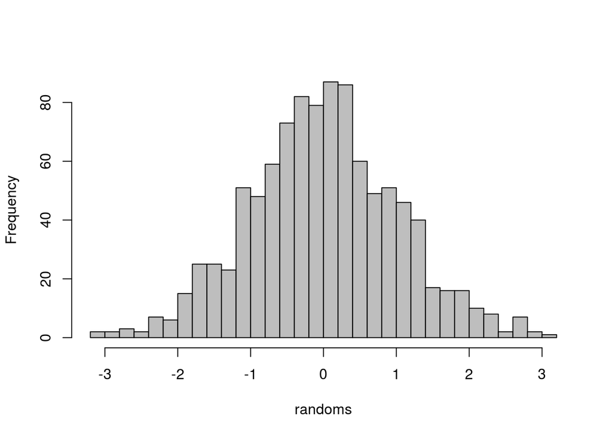

```r
hist(randoms, breaks=30, col="grey", main="")
```

# Inline code chunks

In R Markdown you can also inline “inline” code chunks within paragraphs and other text content. For example, here is the mean of the `randoms` variable that we assigned earlier: -0.002458. In Stencila, we call these `CodeExpression`s, because they are intended to display a calculated value, and shouldn’t be used for statements, such as assigning a variable.